# Assignment 2 Report

Taylor Falk

11/17/2021

**Please read this brief introduction to R Markdown, and complete the second half of the document yourself.**

# R Markdown

R Markdown, `.Rmd` files, are a type of markdown files that can execute R code in an R environment. Markdown is an open source language used for easily creating documents such as web pages and PDFs. Markdown and R Markdown can be used to procedurally generate documents and reports, which have a wide number of use-cases across bioinformatics. Not only can you save time by creating code to automatically draft documents, you can also include detailed instructions and information alongside your code.

## knitr

`knitr` is simply the package R uses to convert the R Markdown into the appropriate output (HTML, PDF, or Word). While there is a deep level of customization available, most users can comfortably create beautiful documents with the default parameters. In order to compile your markdown, in RStudio you can select the `Knit` button below the open file button.

## Markdown Basics

The raw markdown, which you may or may not be looking at, is styled very basically. The largest titles start with one octothorpe `#`. The more `#`’s added, the smaller a title or header becomes.

# Biggest

## 2nd Biggest

### so on

#### and so forth

##### until you have

###### six octothorpes

then nothing happens.

Importantly, two spaces () can be included after a line of text to start a new line.

Markdown can be styled a few different ways:  
`_italics_` -> *italics*  
`**bold**` -> **bold**  
`` `monospace` `` -> `monospace`, good for code

A good cheat sheet is the [Markdown Guide Cheat Sheet](https://www.markdownguide.org/cheat-sheet)

## R Code in Markdown

The really vital part of R Markdown is the inclusion of code snippets you can place into the document, which will run and print out to users. In this snippet I create a function that says hello and that text is printed inside the document.

```r
say_hi <- function() {
  return("Hello world.")
}
print(say_hi())
```

```
## [1] "Hello world."
```

The syntax of the **snippet* is simple, with three back ticks `` ``` `` indicating the start and end of the snippet, and a lower case `r` in curly braces `{}` to indicate what language is used: `{r}` indicates R, `{python}` indicates Python. R Markdown does not support every language, but there are use cases where one document running both R and Python code can prove extremely useful and concise. There is also a button in RStudio to insert a snippet, it is a small green `+C` in the top right of the editor.

I can also test my code in RStudio without having to knit the entire document by pressing the green “Play” arrow on the snippet I am interested in.

Finally, R Markdown scripts can `source()` other `.R` scripts and use them in their execution environment. This mean I can define a function in my `main.R` script and use it in my R Markdown snippets. Note that the converse is true, using `knitr::purl()`, and the code established in an R Markdown can be sourced, and *tested*, using an normal `.R` script.

Also note that the environment is carried from one snippet to another, so if I define a function or load a file in one snippet I can use those objects in later snippets.

```r
message <- 'The last example...for now.'
```

```r
print(paste(message, 'But there\'s always room for more.'))
```

```
## [1] "The last example...for now. But there's always room for more."
```

# Assignment

Using what you know from this document and the `main.R` script, use the functions from `main.R` to draw a boxplot of expression levels. Use this R Markdown document to describe your code as you are using it in this document, as done above. Take time to enhance your ggplot function from the `main.R` script with high quality visual aesthetics. Do not use default ggplot colors.

```r
# use source to load your functions from main.R into this document.
source("main.R")
```

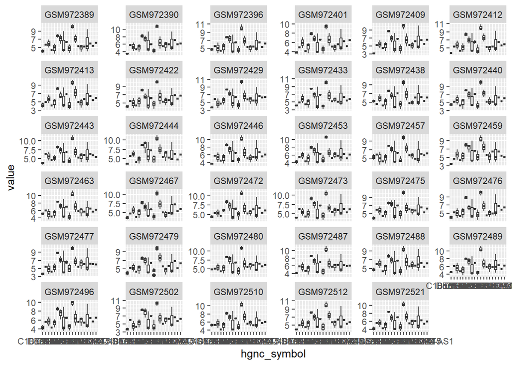

```r
# use source to load your functions from main.R into this document.
source("main.R")
expr <- load_expression("example_intensity_data.csv")
samples <- filter_15(expr)
sample_names <- affy_to_hgnc(samples)
all_names <- sample_names$hgnc_symbol[-which(sample_names$hgnc_symbol == "")]
goodGenes <- sample(all_names, 10)
badGenes <- sample(all_names, 10)
plot_tibble <- reduce_data(expr_tibble = expr, names_ids = sample_names,
                              goodGenes, badGenes)
p <- plot_ggplot(plot_tibble)
p
```